# Séries Temporais - Projeto modelos ARIMA e SARIMA

Túlio Herculano

# Um Estudo Geoespacial do Município de Queimadas-PB

A compreensão da dinâmica climática é de extrema importância, especialmente para municípios cuja economia regional é altamente dependente desse fator. Esse é o caso de diversas cidades de pequeno e médio porte do interior paraibano, que apresentam características climáticas marcantes e singulares.

A base de dados utilizada abrange a região do Cariri Oriental da Paraíba, composta por 12 municípios. No entanto, o escopo desta análise se limitará exclusivamente ao município de Queimadas-PB.

O objetivo central deste estudo é investigar a existência de correlações entre as variáveis selecionadas e, a partir desses dados, obter uma compreensão mais aprofundada sobre o comportamento climático local.

Para isso, serão analisadas as seguintes variáveis:

- Temperatura Média - 2m (ºC)
- Precipitação Total Corrigida - (mm/dia)
- Velocidade do vento - 2m (m/s)
- Umidade Relativa (%)

## Gráfico das Séries

Estamos análisando as variáveis

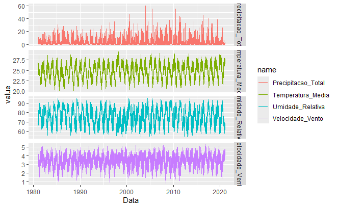

**Observações:**

De foram geral, as variáveis apresentam uma alta variabilidade. Isso nos leva a supor que os modelos adequados para esta situação são os da familida GARCH. Será feito o teste de hipotese para identificar a presença (ou ausência) do efeito GARCH nas séries, por hora daremos continuedade partindo para o processo de compreensão da sazonalidade e tendência.

## Estacionariedade

Como todo estudo do campo de Séries Temporais, inicialmente verificar se há tendencia em algumas das séries para ter um suporte maior no momento de escolhermos os melhores candidatos que devem ser testados na modelagem.

Logo, faremos o teste estatístico para verificar se há ou não tendência nas nossas variáveis.

Temos as seguintes hipoteses:

- *H0:* A série é estacionária (em nível ou tendência).
- *H1:* A é série é não estacionária (possui raiz unitaria).

| municipio | Variavel | kpss_stat | kpss_pvalue |
| --- | --- | --- | --- |
| Queimadas | Precipitacao_Total | 0.1655423 | 0.10000000 |
| Queimadas | Temperatura_Media | 1.3927623 | 0.01000000 |
| Queimadas | Umidade_Relativa | 0.6245997 | 0.02040003 |
| Queimadas | Velocidade_Vento | 0.6195390 | 0.02086009 |

**Observações:**

## ACF e PACF

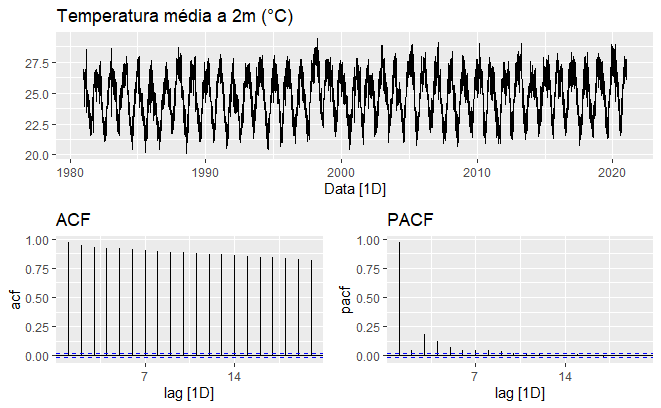

**Observações:**

## Estudo da Sazonalidade

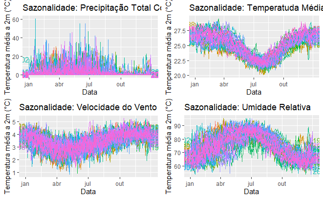

**Observações:**

## Testando Efeito GARCH

```
    ARCH LM-test; Null hypothesis: no ARCH effects

data:  df_final$Temperatura_Media
Chi-squared = 163307, df = 12, p-value < 2.2e-16


    ARCH LM-test; Null hypothesis: no ARCH effects

data:  df_final$Precipitacao_Total
Chi-squared = 24956, df = 12, p-value < 2.2e-16


    ARCH LM-test; Null hypothesis: no ARCH effects

data:  df_final$Velocidade_Vento
Chi-squared = 140465, df = 12, p-value < 2.2e-16


    ARCH LM-test; Null hypothesis: no ARCH effects

data:  df_final$Umidade_Relativa
Chi-squared = 159441, df = 12, p-value < 2.2e-16
```

**Observação:**  
Todas as variáveis apresentaram a presença do efeito GACH, logo, temos o nosso primeiro principal candidato para modelas nossas séries.

Antes de partir para a fase de modelagem, vamos verificar se alguma das séries tem Sazonalidade e Tendência.